# Jupyter Notebook — generated with runcell

| 项目 | 内容 |
| --- | --- |
| 课程 | 数据分析与经济决策（ds2026） |
| 题目 | ex_Team01：T-A2_美股七姐妹财务与股价对比 |
| 小组 | 第 3 组 |
| 成员 | 刘飞龙（25210190）、廖婉琼（25210178）、刘凤里（25210191）、高思远（25210133）、杨艺欣（25210279）、司徒靖（25210231）、莫福群（25210212）、甘立杰（25210131） |
| GitHub | https://github.com/ganlijie-code/ds2026-G03-T-A2 |
| Pages | https://ganlijie-code.github.io/ds2026-G03-T-A2/ |
| 日期 | 2026-05-13 |

### 任务 3：分析与可视化

图 1：标准化股价走势（基期 = 1）

```
import matplotlib.pyplot as plt
import matplotlib.dates as mdates
import pandas as pd

prices = pd.read_csv('./data_raw/prices_raw.csv', index_col=0, parse_dates=True)

# 前向填充（节假日停市产生的缺失）
prices = prices.ffill()
prices_norm = prices / prices.iloc[0]  # 基期归一化

fig, ax = plt.subplots(figsize=(12, 5))
for col in prices_norm.columns:
    ax.plot(prices_norm.index, prices_norm[col], label=col, linewidth=1.5)

ax.set_title('七姐妹股价走势（近 5 年，基期 = 1）', fontsize=14)
ax.set_xlabel('日期')
ax.set_ylabel('相对价格')
ax.legend(loc='upper left', ncol=2)
ax.xaxis.set_major_formatter(mdates.DateFormatter('%Y-%m'))
plt.tight_layout()
plt.savefig('./output/fig_price_trend.png', dpi=150)
plt.show()
```

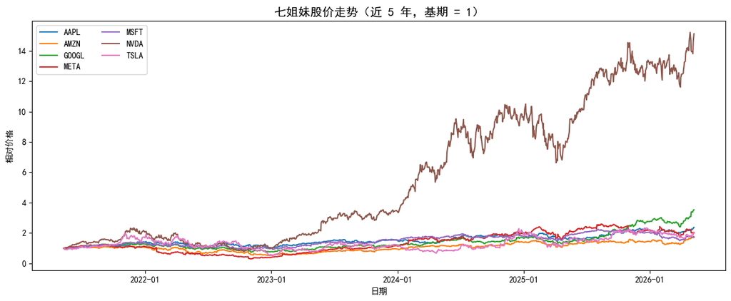

问题1.过去 5 年涨幅最大/最小的是哪家公司？主要受什么事件驱动？

答：以下是涨幅最大和最小分析，以及驱动事件  
一、涨幅最大：NVIDIA（英伟达）  
核心驱动事件：AI 算力革命  
1. 生成式 AI 爆发（2022 年底至今）  
- ChatGPT 的推出引爆全球大模型竞赛，英伟达 GPU（A100、H100、H200、Blackwell 系列）成为训练和推理大模型的唯一主流算力基础设施，出现"一卡难求"的局面。  
- 数据中心业务营收从 2021 年的约 100 亿美元跃升至 2025 财年的超过 1100 亿美元，增长逾 10 倍。  
2. 业绩持续超预期  
- 连续多个季度营收和利润大幅超出华尔街预期，毛利率一度突破 78%，净利润率超过 50%，估值虽高但业绩持续兑现。  
3. CUDA 生态护城河  
- 十数年积累的 CUDA 软件生态使竞争对手（AMD、Intel 及自研芯片）难以短期替代，形成了极强的客户粘性。  
4. 股价复利效应  
- 2021 年中股价仅约 14 美元（拆分调整后），2024 年中一度突破 140 美元，五年内涨幅超 14 倍，贡献了 Magnificent 7 绝大部分超额收益。  
二、涨幅最小：Amazon（亚马逊）  
主要制约因素：  
1. 电商业务增速放缓  
- 后疫情时代（2022-2023 年）线上消费红利消退，电商业务营收增速从疫情期间的 40%+ 回落至个位数。  
- 高通胀环境下消费者支出趋于谨慎，且面临 Temu、Shein 等中国跨境电商的低价竞争。  
2. AWS 增速低于预期  
- AWS 虽仍是全球云计算龙头，但增速从 30%+ 放缓至 2023 年的约 12-13%（后逐步回升），主要受企业 IT 支出收紧影响。  
- 相比微软 Azure 和 Google Cloud 在 AI 领域的积极布局（如 OpenAI 合作），AWS 在生成式 AI 初期的声量相对较弱。  
3. 成本与利润压力  
- 2022-2023 年亚马逊经历了大规模裁员和物流网络优化，前期过度扩张导致成本居高不下，利润率受压。  
- 相较英伟达的"卖铲人"高毛利模式，亚马逊零售业务天然毛利率较低（约 15%），拖累整体估值。  
4. 反垄断与监管压力  
- 美国 FTC 对亚马逊的反垄断诉讼持续发酵，欧洲监管也日趋严格，增加了未来业务分拆或罚款的不确定性。  
三、补充

| 企业（代码） | 关键驱动 / 主要制约 |
| --- | --- |
| AAPL（苹果） | iPhone 与服务等高毛利业务现金流稳健。中国市场竞争加剧；Apple Intelligence 等端侧 AI 落地与监管节奏相对滞后。 |
| MSFT（微软） | OpenAI 重要股东，Azure 与 Copilot 形成较完整的企业级 AI 产品矩阵。市值基数大，股价弹性与「纯 AI 标的」相比相对温和。 |
| NVDA（英伟达） | 生成式 AI 与数据中心 GPU 需求爆发，CUDA 生态护城河深。下游云厂商资本开支偏集中；景气与库存周期波动；地缘政治与出口管制不确定性。 |
| GOOGL（Alphabet） | 搜索广告韧性、YouTube、Google Cloud 基本盘；Gemini 推进全栈 AI 整合。反垄断诉讼与分拆预期压制估值与业务边界。 |
| AMZN（亚马逊） | 电商规模与 AWS 云龙头地位；Bedrock 等补足云侧 AI。电商增速放缓及 Temu、Shein 等低价电商冲击；AWS 增速阶段性低于预期；零售低毛利拖累综合利润率；监管与反垄断风险。 |
| META（Meta） | 2023–2024 年「效率年」降本增效；Reels、Threads 等推荐算法带动广告复苏与利润率修复。2022 年元宇宙重投入与宏观利率冲击下的估值回撤记忆仍在；监管与隐私政策对广告定向的长期约束。 |
| TSLA（特斯拉） | 全球电动车龙头品牌与规模；FSD、Optimus 等「出行+机器人」叙事支撑远期期权价值。销量增速放缓与价格战侵蚀利润；比亚迪等竞品份额上升；高估值对兑现节奏敏感。 |

四、结论  
英伟达凭借 AI 算力的"卖铲人"地位成为 Magnificent 7 中涨幅最大的企业，五年超 14 倍；  
亚马逊则因电商红利消退、AWS 增速放缓及零售业务低毛利属性，成为七巨头中涨幅最小的标的。

图 2：年度收益率热力图

```
import matplotlib.pyplot as plt
import pandas as pd
import numpy as np
import seaborn as sns
import pandas as pd
import numpy as np

prices = pd.read_csv('./data_raw/prices_raw.csv', index_col=0, parse_dates=True)

# 检查缺失值
print(prices.isnull().sum())

# 前向填充（节假日停市产生的缺失）
prices = prices.ffill()

# 计算日度收益率
returns = prices.pct_change().dropna()
#设置全局字体设置，用于中文支持
plt.rcParams['font.sans-serif'] = ['SimHei', 'Microsoft YaHei']
plt.rcParams['axes.unicode_minus'] = False

# 年度收益
annual_returns_by_year = returns.resample('YE').apply(
    lambda x: (1 + x).prod() - 1
) * 100

# 转置数据，使得股票在 Y 轴，年份在 X 轴
data_to_plot = annual_returns_by_year.T

fig, ax = plt.subplots(figsize=(12, 6))

# Create heatmap
sns.heatmap(
    data_to_plot,
    annot=True,
    fmt='.1f',
    cmap='RdYlGn',
    center=0,
    ax=ax,
    linewidths=0.5,
    cbar_kws={'label': '年度收益率 (%)'},
    yticklabels=True, # Ensure y-tick labels are shown
    xticklabels=True  # Ensure x-tick labels are shown
)

# 设置标题
ax.set_title('七姐妹年度收益率热力图 (%)', fontsize=13)
plt.xticks(rotation=45, ha='right')
plt.yticks(rotation=0)

# 使用 tight_layout 自动调整子图参数，使子图适应图形区域。
plt.tight_layout()

# 保存为html
plt.savefig('./output/fig_return_heatmap.png', dpi=150, bbox_inches='tight')
plt.show()
```

AAPL 0 AMZN 0 GOOGL 0 META 0 MSFT 0 NVDA 0 TSLA 0 dtype: int64

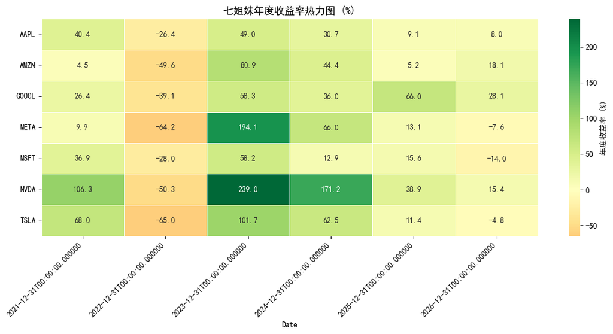

问题2.哪家公司的风险调整后收益（夏普比率）最高？

答：以下收益分析  
一、夏普比率排名

| 排名 | 公司 | 代码 | 夏普比率 | 年化收益率 | 年化波动率 |
| --- | --- | --- | --- | --- | --- |
| 1 | NVIDIA | NVDA | 1.2251 | 67.79% | 51.66% |
| 2 | Alphabet | GOOGL | 0.8229 | 30.17% | 31.20% |
| 3 | Apple | AAPL | 0.6035 | 21.09% | 27.49% |
| 4 | Tesla | TSLA | 0.4600 | 31.60% | 58.90% |
| 5 | Meta | META | 0.4383 | 23.74% | 43.90% |
| 6 | Microsoft | MSFT | 0.3873 | 14.72% | 26.39% |
| 7 | Amazon | AMZN | 0.3538 | 17.03% | 35.42% |

[output not shown]

三、结论  
NVIDIA 夏普比率最高（1.2251），本质上是 AI 算力超级周期中"垄断性高收益"对"高波动"的完全覆盖。但过去五年的极致表现不可简单外推。随着竞争加剧、基数抬高和市场对 AI ROI 的审视，NVDA 的夏普比率面临均值回归压力。对投资者而言，当前的高夏普比率反映的是"已经兑现的繁荣"，而非未来必然持续的超额风险调整后收益。

图 3：风险-收益散点图

```
import matplotlib.pyplot as plt
import pandas as pd
import numpy as np
import seaborn as sns
# 显示中文
plt.rcParams['font.sans-serif'] = ['SimHei']
plt.rcParams['axes.unicode_minus'] = False
metrics = pd.read_csv('./data_clean/metrics.csv', index_col=0)
fig, ax = plt.subplots(figsize=(9, 7))
for tk in metrics.index:
    ax.scatter(metrics.loc[tk, '年化波动率'] * 100,
               metrics.loc[tk, '年化收益率'] * 100,
               s=100, zorder=5)
    ax.annotate(tk,
                xy=(metrics.loc[tk, '年化波动率'] * 100,
                    metrics.loc[tk, '年化收益率'] * 100),
                xytext=(5, 5), textcoords='offset points', fontsize=10)

ax.set_xlabel('年化波动率 (%)')
ax.set_ylabel('年化收益率 (%)')
ax.set_title('风险-收益分布（近 5 年）', fontsize=13)
ax.axhline(0, color='gray', linewidth=0.5, linestyle='--')
plt.tight_layout()
plt.savefig('./output/fig_risk_return.png', dpi=150)
```

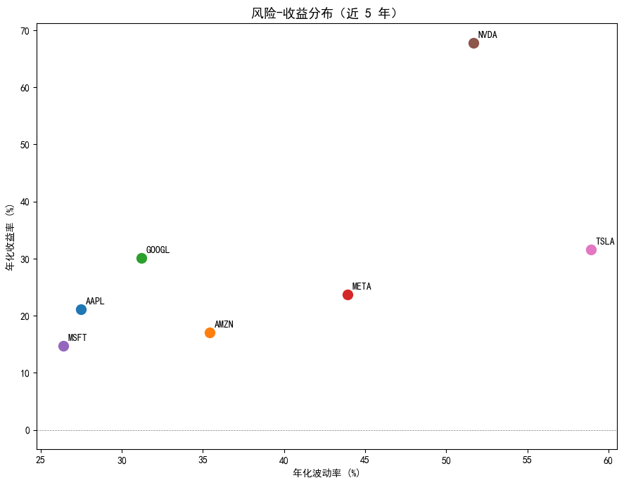

问题3.七家公司的估值是否处于合理区间？相互之间的差异如何解释？

答：以下是公司估计的合理区间判断及解释  
一、估值概览与合理区间判断

| 公司 | 市盈率 (PE) | 市净率 (PB) | 营收增速 | PEG（PE/增速） | 估值判断 |
| --- | --- | --- | --- | --- | --- |
| META | 22.18 | 6.35 | 33.1% | 0.67 | ⭐ 偏低/合理 |
| NVDA | 43.83 | 33.25 | 73.2% | 0.60 | ⭐ 合理（高增消化） |
| MSFT | 24.75 | 7.44 | 18.3% | 1.35 | 合理 |
| GOOGL | 30.57 | 11.66 | 21.8% | 1.40 | 合理 |
| AMZN | 32.58 | 6.64 | 16.6% | 1.96 | ⚠️ 偏高 |
| AAPL | 35.46 | 40.39 | 16.6% | 2.14 | ⚠️ 偏高（PB失真） |
| TSLA | 400.33 | 19.56 | 15.8% | 25.34 | ❌ 严重失真/不合理 |

[output not shown]

四、总结  
估值最合理的公司：NVDA、META（高增消化估值，PEG < 1）  
估值处于合理中枢：MSFT、GOOGL（PEG 1.3-1.4，匹配增速与确定性）  
估值偏高：AMZN、AAPL（增速放缓但 PE 仍维持高位，依赖品牌护城河溢价）  
估值失真/高风险：TSLA（当期利润崩塌导致 PE 失效，定价完全依赖远期故事）  
若追求估值安全边际，应关注 META；若看好 AI 算力高增的确定性，NVDA的高 PE 并非泡沫；而TSLA 的估值对基本面投资者而言，当前缺乏可靠的锚定点。

图 4：估值指标对比（PE、PB 双轴柱状图）

```
import matplotlib.pyplot as plt
import pandas as pd
import numpy as np
import seaborn as sns

financials = pd.read_csv('./data_raw/financials_raw.csv', index_col='ticker')

fig, ax1 = plt.subplots(figsize=(16, 9))
x = range(len(financials))
bars1 = ax1.bar([i - 0.2 for i in x], financials['trailingPE'],
                width=0.35, label='PE（市盈率）', color='steelblue', alpha=0.8)
ax1.set_ylabel('市盈率（PE）')
ax1.set_xticks(list(x))
ax1.set_xticklabels(financials.index)

ax2 = ax1.twinx()
bars2 = ax2.bar([i + 0.2 for i in x], financials['priceToBook'],
                width=0.35, label='PB（市净率）', color='darkorange', alpha=0.8)
ax2.set_ylabel('市净率（PB）')

lines = [bars1, bars2]
ax1.legend(lines, ['PE（市盈率）', 'PB（市净率）'], loc='upper left')
ax1.set_title('七姐妹估值对比：PE 与 PB', fontsize=13)
plt.tight_layout()
plt.savefig('./output/fig_valuation.png', dpi=150)
```

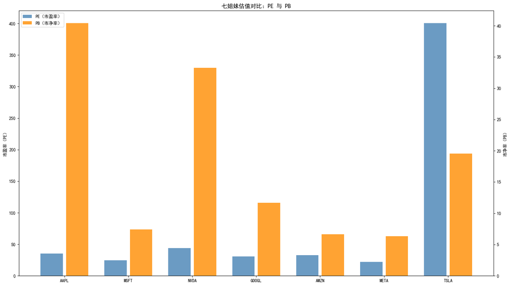

问题4.你观察到哪些你认为值得深入研究的规律或异常？

答：以下是值得深入研究的规律与异常  
一、统计显著的异常值（Z-score > 1.5）  
异常 1：Tesla（TSLA）— 双重极端异常

| 指标 | 数值 | Z-score | 含义 |
| --- | --- | --- | --- |
| 市盈率 | 400.3 | +2.26 | 静态盈利几乎为零，PE 公式失效 |
| 毛利率 | 19.1% | -1.85 | 七巨头中唯一毛利率低于 20% 的公司 |

值得研究的问题：TSLA 的估值体系与其他六家完全不同——它不被当作科技公司定价，而是"制造业+未来期权"的混合体。其 400 倍 PE 并非泡沫信号，而是 trailing EPS 因价格战崩塌导致的数学失真。这引发一个深层问题：用传统 PE/PB 框架分析 TSLA 是否本质上就是错误的？  
异常 2：Apple（AAPL）— 会计扭曲的镜像

| 指标 | 数值 | Z-score | 含义 |
| --- | --- | --- | --- |
| 市净率 | 40.4 | +1.62 | 账面净资产被压缩至极低水平 |
| ROE | 141.5% | +1.79 | 净资产分母过小导致的虚高 |

值得研究的问题：AAPL 的 PB 和 ROE 是同源异常——过去十年超万亿美元的激进股票回购将账面净资产不断注销，造成 ROE 虚高、PB 虚高。这揭示了一个重要规律：对回购型公司，PB 和 ROE 作为估值/盈利指标会系统性失效。若用 ROIC（投入资本回报率）替代 ROE，苹果的盈利画像可能完全不同。  
异常 3：NVIDIA（NVDA）— 增长的孤峰

| 指标 | 数值 | Z-score | 含义 |
| --- | --- | --- | --- |
| 营收增速 | 73.2% | +2.17 | 增速是第二名的 2.2 倍 |

值得研究的问题：NVDA 的增速在七巨头中形成明显的单峰分布（其他六家增速 15-33%）。这种"断层式领先"是否可持续？一旦增速从 70%+ 回落至 30%（仍远高于同行），市场是否会用"增速腰斩"的逻辑重新定价？  
二、反直觉的规律  
规律 1：市值与市盈率呈负相关（r = -0.486）

| 市值排名 | 公司 | PE 排名 |
| --- | --- | --- |
| 1 | NVDA | 2（高估值） |
| 2 | GOOGL | 5（中估值） |
| 3 | AAPL | 3（中高估值） |
| 4 | MSFT | 6（低估值） |
| 5 | AMZN | 4（中估值） |
| 6 | TSLA | 1（极端估值） |
| 7 | META | 7（最低估值） |

| 排序方向 | 第1位 | 第2位 | 第3位 | 第4位 | 第5位 | 第6位 | 第7位 |
| --- | --- | --- | --- | --- | --- | --- | --- |
| PE 排序（高→低） | TSLA | NVDA | AAPL | AMZN | GOOGL | MSFT | META |
| 毛利率排序（高→低） | META | NVDA | MSFT | GOOGL | AMZN | AAPL | TSLA |

反直觉之处：按理说高毛利率应享有高估值，但数据显示毛利率越低，PE 反而越高。  
样本中只有 7 家公司，TSLA 的极端 PE（400）和极端低毛利（19%）是主要驱动因素。剔除 TSLA 后，这一相关性会大幅减弱。但这恰恰说明 TSLA 在七巨头中是一个彻底的"异类"——它打破了科技股的估值-盈利质量关联。  
规律 3：毛利率排名与 ROE 排名严重错位

| 公司 | 毛利率排名 | ROE 排名 | 错位差 |
| --- | --- | --- | --- |
| META | 1（81.9%） | 5（32.9%） | -4 |
| AAPL | 6（47.9%） | 1（141.5%） | +5 |
| NVDA | 2（71.1%） | 2（101.5%） | 0 |
| TSLA | 7（19.1%） | 7（4.9%） | 0 |

值得研究的问题：  
META：毛利率第一，ROE 仅第五。这意味着其巨额毛利被管理费用、研发投入或资本结构大量侵蚀。可能原因：Reality Labs（元宇宙）年亏损超 160 亿美元，直接拉低整体 ROE。  
AAPL：毛利率第六，ROE 第一。这验证了前述的"回购扭曲"——ROE 高并非因为经营效率无敌，而是因为净资产被回购压得太低。  
三、复合指标揭示的深层结构  
指标 A：Growth × Margin（质量增长）  
衡量"增速是否有利润支撑"：

| 排名 | 公司 | 数值 | 解读 |
| --- | --- | --- | --- |
| 1 | NVDA | 0.520 | 增速快且毛利高，增长质量碾压 |
| 2 | META | 0.271 | 增速高、毛利极高，但 ROE 被元宇宙拖累 |
| 3 | GOOGL | 0.132 | 中规中矩 |
| 7 | TSLA | 0.030 | 增速慢且毛利低，"质量增长"垫底 |

规律：NVDA 的 0.52 是第二名 META 的 1.9 倍，形成断层领先。这说明 NVDA 不仅增长快，而且这种增长是高毛利、高壁垒的，与其他公司的增长有本质区别。  
指标 B：Growth / PE（估值性价比）  
衡量"为每单位增长支付的价格"：

| 排名 | 公司 | 数值 | 解读 |
| --- | --- | --- | --- |
| 1 | NVDA | 0.0167 | 增长最快，PE 并非最高，性价比最优 |
| 2 | META | 0.0149 | 增长较快，PE 最低，性价比极佳 |
| 7 | TSLA | 0.0004 | 增速最慢，PE 最高，性价比灾难 |

规律：NVDA 和 META 构成了七巨头中的 "估值性价比双雄"——它们以相对合理（甚至偏低）的估值，提供了最高的增长回报。而 AAPL/AMZN/TSLA 则处于"低增长、高估值"的陷阱区间。  
四、相关性矩阵的隐藏信号

|  | marketCap | trailingPE | priceToBook | revenueGrowth | grossMargins | returnOnEquity |
| --- | --- | --- | --- | --- | --- | --- |
| marketCap | 1.000 | -0.486 | 0.538 | 0.453 | 0.238 | 0.670 |
| trailingPE | -0.486 | 1.000 | 0.092 | -0.226 | -0.826 | -0.413 |
| priceToBook | 0.538 | 0.092 | 1.000 | 0.371 | -0.239 | 0.862 |
| revenueGrowth | 0.453 | -0.226 | 0.371 | 1.000 | 0.496 | 0.371 |
| grossMargins | 0.238 | -0.826 | -0.239 | 0.496 | 1.000 | 0.186 |
| returnOnEquity | 0.670 | -0.413 | 0.862 | 0.371 | 0.186 | 1.000 |

信号 1：PB 与 ROE 高度正相关（r = 0.862）  
这符合经典估值理论（高 ROE → 高 PB），但 AAPL 是这个规律的极端体现——其 ROE/PB 比值（0.035）仅排第四，说明市场并未完全按其账面 ROE 给予 PB 溢价，可能已部分识别了回购扭曲。  
信号 2：市值与 ROE 正相关（r = 0.670），但与 PE 负相关（r = -0.486）  
这意味着市场给大市值公司定价时，更看重其盈利能力（ROE），而非增长弹性（PE）。对大公司的估值逻辑是"赚确定性的钱"，对小公司则是"赌未来的增长"。  
五、总结：最值得深入研究的三个方向

| 研究方向 | 核心问题 | 数据支撑 |
| --- | --- | --- |
| 1. TSLA 的估值体系重构 | 当 trailing PE=400 时，传统估值框架是否已失效？应使用什么指标（P/S、P/FCF、期权定价）？ | PE、毛利率均为极端异常值 |
| 2. 股票回购对财务指标的系统性扭曲 | AAPL 的 ROE=141%、PB=40 在多大程度上是"回购会计"的产物？若用 ROIC 替代，七巨头的盈利排名会如何变化？ | AAPL 的 PB、ROE 同时异常 |
| 3. NVDA 的"断层式增长"可持续性 | 增速 73% 是第二名 META 的 2.2 倍，这种单峰领先是技术垄断的结果还是周期性的？增速回落至 30% 时估值如何重估？ | 营收增速 Z-score=2.17 |